Plotting chromosomes Fernando Roa 23 08 2019

Vignette 2. Circular Plots  
Vignette 3. Phylogeny  
Vignette 4. Human karyotype  
Vignette 5. Credits

[figure not shown]

# 1 Plotting chromosomes

This guide shows how to plot idiograms of measured karyotypes and optionally marks.

For help on Citrus karyotypes, visit: https://ferroao.gitlab.io/idiogramfishhelppages/citrushelp.html

## 1.1 Load package

visit gitlab for installation instructions https://gitlab.com/ferroao/idiogramFISH

```r
#load package
library(idiogramFISH)
```

## 1.2 Plot monocentrics

Initially you have to put your chromosome data in a data.frame.

### From scratch:

```r
# Example data.frame to write in R, use: (column OTU is optional if only 1 OTU)
mydfChrSize<-read.table(text=
"            OTU chrName shortArmSize longArmSize
  \"Species one\"   1     1.5         2.0
  \"Species one\"   2     2.0         2.5
  \"Species one\"   3     1.0         1.5
  \"Species one\"   B     2.0         3.5"  ,  header=TRUE, stringsAsFactors=FALSE,fill=TRUE)
```

| OTU | chrName | shortArmSize | longArmSize |
| --- | --- | --- | --- |
| Species one | 1 | 1.5 | 2.0 |
| Species one | 2 | 2.0 | 2.5 |
| Species one | 3 | 1.0 | 1.5 |
| Species one | B | 2.0 | 3.5 |

### loading saved data:

If you use RStudio, in the menu “Session”, use “Set working directory” for choosing your desired folder or:

```r
setwd("~/folder/subfolder")
```

Open your chromosome data data.frame importing it from a .csv (read.csv) or .xls file (readxl).

```r
mydfChrSize<-read.csv("somefile.csv")
```

Editing a data.frame:

```r
bigdfOfChrSize <- edit(bigdfOfChrSize, edit.row.names = FALSE)
```

For fixing column names use:

```r
colnames(mydfChrSize)<-c("OTU", "chrName","shortArmSize","longArmSize")
```

top

### Get marks general data

This data.frame is optional.

Put your mark data in a data.frame. This data.frame has the marks present in all karyotypes without position info. If the `style` column is not present, param. `defaultStyleMark = "square"` will be used during plotting.

Note the `cenStyle` to make constrictions, mimicking centromeres, and `upArrow` and `downArrow` styles.

```r
# From scratch:
mydfMarkColor<-read.table(text=
" markName markColor  style
        5S      red       dots
       45S      green     square
     gene1      orange    upArrow
     gene2      salmon    downArrow
     gene3      \"#056522\" cMLeft
      DAPI      blue      cM
\"cB mark\"     black     cenStyle
       CMA      yellow    square
\"B mark\"      black     square"  ,  header=TRUE, stringsAsFactors=FALSE,fill=TRUE)
```

| markName | markColor | style |
| --- | --- | --- |
| 5S | red | dots |
| 45S | green | square |
| gene1 | orange | upArrow |
| gene2 | salmon | downArrow |
| gene3 | #056522 | cMLeft |
| DAPI | blue | cM |
| cB mark | black | cenStyle |
| CMA | yellow | square |
| B mark | black | square |

For fixing column names use:

```r
colnames(mydfMarkColor)<-c("markName", "markColor","style")
# if style column is not present it will be filled with "square"
```

top

### Get marks positions data

Open or write your mark positions in a data.frame. This data.frame has the marks present in all karyotypes with position info. This data.frame has also the centromeric marks present in all karyotypes.

```r
# We will use column OTU if data.frame because chromosome size df has it
mydfOfMarks<-read.table(text=
"            OTU chrName markName chrRegion markSize markDistCen
\"Species one\"      1      45S       p       NA         NA     # no measure means whole arm for square marks
\"Species one\"      1       5S       q      0.5         0.5
\"Species one\"      B  \"B mark\"    w       NA         NA     # w for whole chromosome for square marks
\"Species one\"      B  \"cB mark\"   q       NA         1.0
\"Species one\"      2     45S        p        1         1.0
\"Species one\"      2     gene1      q      0.5         1.0
\"Species one\"      2     gene2      q      0.5         2.0
\"Species one\"      3     DAPI       q       NA          1
\"Species one\"      3     gene3      p       NA         .5
\"Species one\"      1     DAPI       cen
\"Species one\"      3      CMA       cen", header=TRUE, stringsAsFactors=FALSE,fill=TRUE)
```

| OTU | chrName | markName | chrRegion | markSize | markDistCen |
| --- | --- | --- | --- | --- | --- |
| Species one | 1 | 45S | p | NA | NA |
| Species one | 1 | 5S | q | 0.5 | 0.5 |
| Species one | B | B mark | w | NA | NA |
| Species one | B | cB mark | q | NA | 1.0 |
| Species one | 2 | 45S | p | 1.0 | 1.0 |
| Species one | 2 | gene1 | q | 0.5 | 1.0 |
| Species one | 2 | gene2 | q | 0.5 | 2.0 |
| Species one | 3 | DAPI | q | NA | 1.0 |
| Species one | 3 | gene3 | p | NA | 0.5 |
| Species one | 1 | DAPI | cen | NA | NA |
| Species one | 3 | CMA | cen | NA | NA |

For fixing column names use something like:

```r
colnames(mydfMarkColor)<-c("OTU", "chrName","markName","chrRegion","markSize","markDistCen")
```

top

### Add some text to the right

For ver. > 1.7

```r
# We will use column note to add a note to the right of the karyotype of the OTU in column OTU
notesdf<-read.table(text=
"            OTU    note
\"Species one\"   \"Author notes\"  ", header=TRUE, stringsAsFactors=FALSE,fill=TRUE)
```

For adding just the OTU name (from column `OTU` of data.frame of chr. size) to the right, use `OTUasNote=TRUE`

### Plotting

You can plot without marks (use only 1st data.frame), but we will use all 4 data.frames created. By default the function will calculate indices (Romero-Zarco, 1986; Watanabe *et al.*, 1999) and morphological categories of [Guerra](https://ferroao.gitlab.io/guerra1986/Guerra1986.pdf) (1986) and Levan (1964). Use parameters `chrIndex` and `morpho` of the function `plotIdiograms` to modify that. See `?plotIdiograms`.

The `cM` style of mark always adds the name as if `legend="inline"`, even when `legend="aside"` (default).

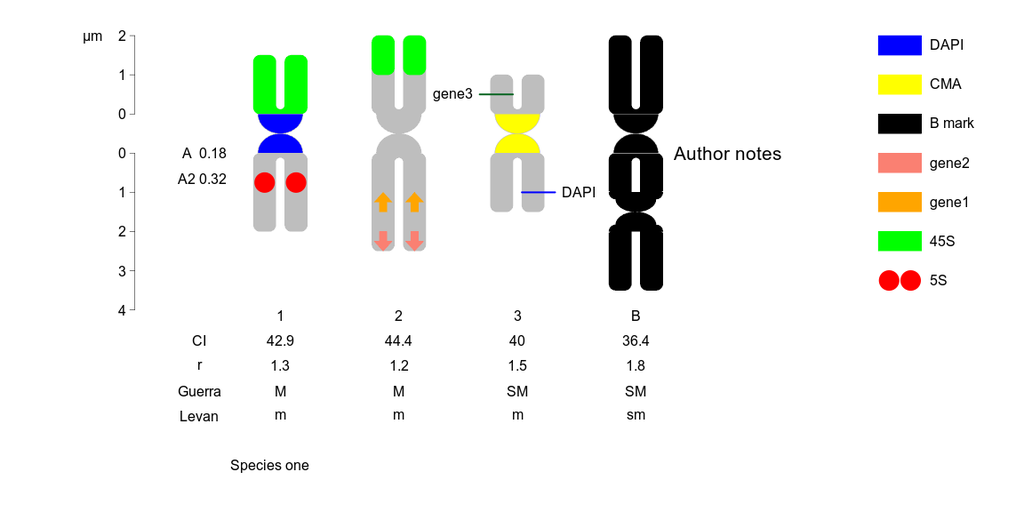

```r
# svg("mydfChrSize.svg",width=12,height=6 )

par(mar = c(0, 0, 0, 0))

plotIdiograms(dfChrSize= mydfChrSize,     # chr. size data.frame
              dfMarkPos= mydfOfMarks,     # mark position data.frame (inc. cen.)
              dfMarkColor=mydfMarkColor,  # mark style d.f.

              chrSpacing=.6,              # separ. among chr.
              distTextChr = .7,           # separation among text and chr. names and ind.
              orderChr = "name",        # order chr. by name
              karHeiSpace=1.6             # vertical size of karyotype including spacer

              ,arrowhead = .5             # proportion of head of arrow

              ,fixCenBorder = TRUE        # use chrColor as border color of cen. or cen. marks
              ,legendWidth = .8           # legend item width
              ,legendHeight = .5          # legend item height
              ,markLabelSpacer = 2        # legend spacer
              ,lwd.mimicCen = 2.5         # constric. mark line width

              ,rulerPos=0                 # ruler position
              ,ruler.tck=-0.01            # ticks of ruler size and orientation
              ,ylabline = -6              # ruler units pos.

              ,notes=notesdf              # data.frame with notes NEW
              ,notesTextSize = 1.3        # font size of notes
              ,notesPos = .2              # space from chr. (right) to note

              ,ylimBotMod = 1             # modify ylim bottom argument
              ,ylimTopMod = 0             # modify ylim top argument
              ,xlimLeftMod = 2            # modify left xlim
              ,xlimRightMod = 3           # modify right xlim
              ,lwd.cM = 2                 # thickness of cM marks
              ,pattern = "^c"             # regex pattern to remove from mark names
              ,remSimiMarkLeg=TRUE        # remove pseudoduplicated mark names from legend (same after pattern removal)
              # ,legend="inline"            # legend next to chr.
              # ,bannedMarkName = "cB mark" # remove from legends
)
```

```r
# dev.off()
```

Vertices when `centromereSize=0` are rounded:

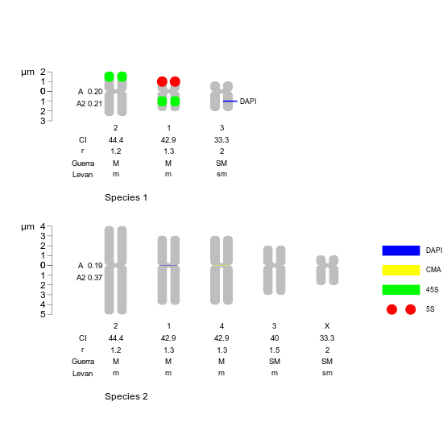

```r
png("mydfChrSize2.png", width=550, height=550)
par(mar = c(0, 0, 0, 0))
plotIdiograms(dfChrSize   = bigdfOfChrSize[1:8,],  # chr. size data.frame
              dfMarkColor = mydfMarkColor,# mark style df
              dfMarkPos   = bigdfOfMarks, # mark position df

              centromereSize = 0,         # <- HERE

              squareness=3,               # vertices squareness
              chrSpacing = .7,            # space among chr.
              karHeight = 2,              # karyotype rel. height
              karHeiSpace=4,              # vertical size of karyotype including spacer
              amoSepar= 2.5,              # separation among karyotype

              indexIdTextSize=.8,         # font size of chr. name and indices
              karIndexPos = .1,           # position of kar. index
              markLabelSize=.7,           # font size of mark legends
              fixCenBorder = FALSE,       # do not use chrColor as border color of cen. or cen. marks
              distTextChr = .8,           # separation among chr. and ind.

              rulerPos= 0,                # ruler position
              ruler.tck=-0.01,            # ticks of ruler size and orientation
              ylabline = -3,              # ruler units pos.

              xlimLeftMod = 2,            # modify xlim left argument
              ylimBotMod = 0.4,           # modify ylim bottom argument
              ylimTopMod = 0              # modify ylim top argument
              ,lwd.cM = 2                 # thickness of cM marks
              )
dev.off()
```

There is no need to add `dfMarkColor` and you can also use the parameter `mycolors` (optional too), to establish marks’ colors. Colors are assigned depending on the order of marks, i.e.:

```r
unique(mydfOfMarks$markName)
```

Let’s use the `cM` style of marks. A protruding line.

`cM` style does not apply to centromere marks. To make something similar, use `centromereSize=0`, `legend="inline"` and `fixCenBorder = FALSE`.

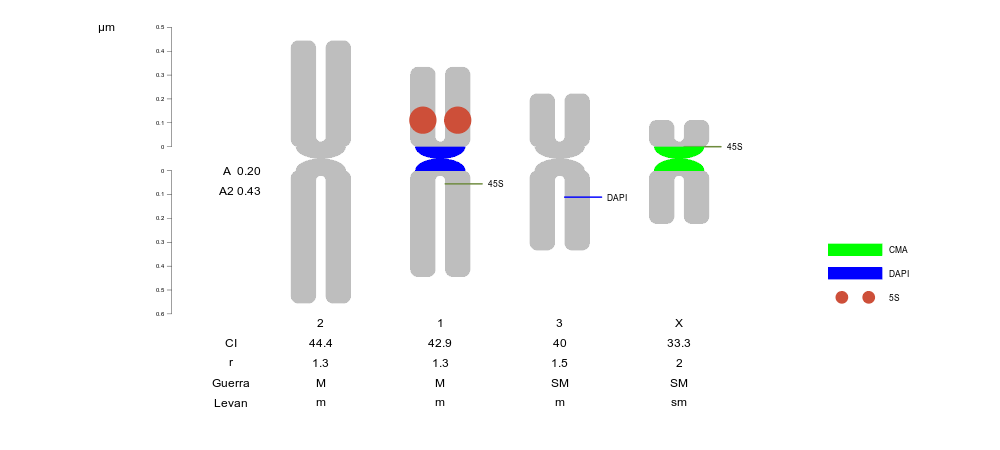

```r
charVectorCol <- c("tomato3","darkolivegreen4","dfsd","blue","green")

# Modify size of kar. to use rulerInterval and ceilingFactor (>= 1.13)
quo<-9
dfOfChrSize2<-dfOfChrSize
dfOfChrSize2$shortArmSize<-dfOfChrSize$shortArmSize/quo
dfOfChrSize2$longArmSize<-dfOfChrSize$longArmSize/quo
dfOfMarks2b<-dfOfMarks2
dfOfMarks2b$markSize<-dfOfMarks2$markSize/quo
dfOfMarks2b$markDistCen<-dfOfMarks2$markDistCen/quo

png("dfOfChrSizeVector.png", width=1000, height=450)
par(mar=rep(0,4))
plotIdiograms(dfChrSize = dfOfChrSize2,    # d.f. of chr. sizes
              dfMarkPos = dfOfMarks2b,     # d.f. of marks' positions
              defaultStyleMark = "cM",     # forces "cM" style in d.f dfMarkColor (exc. 5S)

              mycolors = charVectorCol,    # colors to use

              distTextChr = .5,            # separ. text and chr.

              markLabelSize=.7,            # font size for labels (legend)
              lwd.cM=2,                    # width of cM marks
              legendWidth=0.9,             # legend item width
              legendHeight=.5,

              rulerPos= 0,                 # ruler position
              ruler.tck=-0.01,             # ruler tick orientation and length
              rulerNumberSize=.5           # ruler font size
              ,ylabline = -8               # ruler units pos.

              ,xlimRightMod = 1            # modify xlim right arg.
)
dev.off() # close png
```

top

## 1.3 Plot holocentrics

Initially you have to put your chromosome data in a data.frame. For simplicity, I call a holocen. karyotype anything without centromeres. This is recognized by the absence of columns: “shortArmSize”, etc.

### From scratch:

```r
# Example data.frame written in R, use: (column OTU is optional if only 1 OTU)
mydfChrSizeHolo<-read.table(text=
"            OTU chrName chrSize
\"Species one\"   1     6.5
\"Species one\"   2     5.0
\"Species one\"   3     4.0
\"Species one\"   4     4.0
\"Species one\"   X     3.0    "  ,  header=TRUE, stringsAsFactors=FALSE,fill=TRUE)
```

| OTU | chrName | chrSize |
| --- | --- | --- |
| Species one | 1 | 6.5 |
| Species one | 2 | 5.0 |
| Species one | 3 | 4.0 |
| Species one | 4 | 4.0 |
| Species one | X | 3.0 |

### or loading saved data:

If you use RStudio, in menu “Session”, open “Set working directory” for choosing your desired folder or:

```r
setwd("~/folder/subfolder")
```

Open your chromosome data as data.frame importing it from a .csv (read.csv) or .xls file (readxl).

```r
mydfChrSize<-read.csv("somefile.csv")
```

For fixing column names use:

```r
colnames(mydfChrSize)<-c("OTU", "chrName","chrSize")
```

top

### Get marks general data

This data.frame is optional for ver. > 1.0.0

```r
packageVersion("idiogramFISH")
```

Put your mark data in a data.frame. This data.frame has the marks present in all karyotypes without position info. If the `style` column is not present, param. `defaultStyleMark = "square"` will be used during plotting.

```r
# From scratch:
mydfMarkColor<-read.table(text=
"  markName markColor  style
1       5S       red   dots
2      45S     green square
3     DAPI      blue square
4      CMA    yellow square"  ,  header=TRUE, stringsAsFactors=FALSE,fill=TRUE)
```

| markName | markColor | style |
| --- | --- | --- |
| 5S | red | dots |
| 45S | green | square |
| DAPI | blue | square |
| CMA | yellow | square |

For fixing column names use:

```r
colnames(mydfMarkColor)<-c("markName", "markColor","style")
# if style column not present it will be filled with "square"
```

top

### Get marks positions data

Open or write your mark positions in a data.frame. This data.frame has the marks present in all karyotypes with position info.

```r
# We will use column OTU if data.frame because chromosome size df has it
mydfMarkPosHolo<-read.table(text=
"             OTU  chrName markName markPos markSize chrRegion
\"Species one\"       4        B      NA       NA        w           # whole chromosome mark, use 'w' in col. chrRegion
\"Species one\"       3     DAPI     2.0      0.5
\"Species one\"       1      45S     2.0      0.5
\"Species one\"       2     DAPI     2.0      0.5
\"Species one\"       X      CMA     2.0      0.5
\"Species one\"       X       5S     0.5      0.5
\"Species one\"       X       5S     0.5      0.5"  ,  header=TRUE, stringsAsFactors=FALSE,fill=TRUE)
```

| OTU | chrName | markName | markPos | markSize | chrRegion |
| --- | --- | --- | --- | --- | --- |
| Species one | 4 | B | NA | NA | w |
| Species one | 3 | DAPI | 2.0 | 0.5 |  |
| Species one | 1 | 45S | 2.0 | 0.5 |  |
| Species one | 2 | DAPI | 2.0 | 0.5 |  |
| Species one | X | CMA | 2.0 | 0.5 |  |
| Species one | X | 5S | 0.5 | 0.5 |  |
| Species one | X | 5S | 0.5 | 0.5 |  |

For fixing column names use something like:

```r
colnames(mydfMarkColor)<-c("OTU", "chrName","markName","markPos","markSize")
```

top

### Plotting

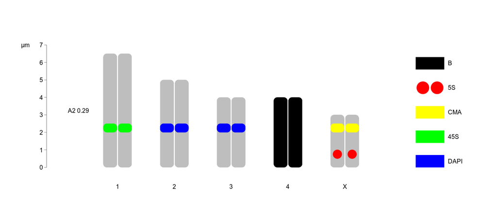

```r
# library(idiogramFISH)
# svg("mydfChrSizeHolo.svg",width=13.5,height=6 )
# png("mydChrSizeHolo.png", width=600, height=300)

par(mar=c(0,4,0,1)) # bottom left top right

plotIdiograms(dfChrSize  = mydfChrSizeHolo,# data.frame of chr. sizes
              dfMarkColor= mydfMarkColor,  # df of mark style
              dfMarkPos  = mydfMarkPosHolo,# df of mark positions
              addOTUName=FALSE,            # add OTU names

              xlimLeftMod= 1,              # modify xlim left argument
              ylimTopMod= -1,              # modify ylim top argument
              ylimBotMod= -2               # modify ylim bottom argument
              ,rulerPos = 0                # ruler position
              ,ruler.tck = -0.01           # ruler ticks size and orient.

              ,legendWidth=1               # width of legend
              ,legendHeight=.7             # height of legend item
              ,xModifier=0.01              # separation among chromatids
)
```

```r
# dev.off() # closes png or svg
```

It is not mandatory to use `dfMarkColor` and you can also use the parameter `mycolors` (optional too), to establish marks’ colors. When using `mycolors`, colors are assigned depending on the order of marks, i.e.:

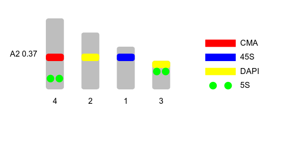

```r
unique(dfMarkPosHolo$markName)
# [1] "5S"   "DAPI" "45S"  "CMA"
par(mar=rep(0,4))
plotIdiograms(dfChrSize = dfChrSizeHolo, # d.f. of chr. size
              dfMarkPos  = dfMarkPosHolo, # d.f. of marks' positions
              mycolors   = c("green","yellow","blue","red"),  # colors for marks

              addOTUName=FALSE,           # do not add OTU name
              ruler=FALSE,                # do not add ruler
              xlimLeftMod=1,              # modify left xlim arg.
              xlimRightMod=3,             # modify right xlim arg.
              ylimBotMod=.2               # modify bottom ylim
              ,chromatids=FALSE           # do not show separ. chromatids
)
```

top

## 1.4 Plot holo. and mono. in the same karyotype

To accomplish this, we will use `cenStyle` marks in a (modified) holocen. karyotype. The ruler is continuous as in holocen.

```r
# mark general characteristics' data.frame:
mydfMarkColor2<-read.table(text=
"  markName markColor  style
1       5S       red   dots
2      45S     green   square
3     DAPI      blue   square
4      CMA    yellow   square
5     c45S     green   cenStyle # <- simulate Cen.
6      c5S       red   cenStyle
7       cB     black   cenStyle
8   constr        NA   cenStyle
9        B     black   square"  ,  header=TRUE, stringsAsFactors=FALSE,fill=TRUE)

# add new marks to data.frame of marks' position
mydfMarkPosHolo2<-plyr::rbind.fill(mydfMarkPosHolo,data.frame(OTU="Species one",
                                                             chrName=1:4,
                                                             markName=c("c45S","c5S","constr","cB"), # <- use new mark
                                                             markPos=2.5,
                                                             markSize=NA
                                                             )
                  )
```

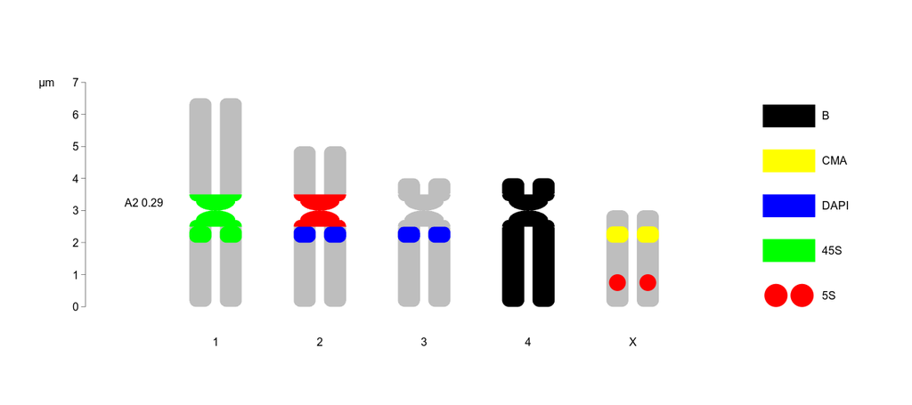

```r
# png("mydChrSizeHolo.png", width=600, height=300)
par(mar=c(0,4,0,1)) # bottom left top right

plotIdiograms(dfChrSize  = mydfChrSizeHolo,# data.frame of chr. sizes
              dfMarkColor= mydfMarkColor2,  # df of mark style
              dfMarkPos  = mydfMarkPosHolo2,# df of mark positions
              addOTUName=FALSE,            # add OTU names

              xlimLeftMod= 1,              # modify xlim left argument
              ylimTopMod= -1,              # modify ylim top argument
              ylimBotMod= -2               # modify ylim bottom argument
              ,rulerPos = 0
              ,ruler.tck = -0.01

              ,legendWidth=1               # width of legend
              ,legendHeight=.7             # height of legend item
              ,lwd.mimicCen=2.5            # line width of const. mark
              ,pattern="^c"                # regex pattern to remove from mark names
              ,remSimiMarkLeg = TRUE       # remove pseudoduplicated mark names (got equal after pattern removal)
              # ,legend="inline"             # legends inline
              # ,bannedMarkName = c("c45S","cB") # do not use this names from labels
)
```

```r
# dev.off() # closes png or svg
```

## 1.5 Example with several species (OTUs) - mono.

To illustrate this, we will load some data.frames from the package

- Chromosome sizes

```r
head(bigdfOfChrSize,15)
```

| OTU | chrName | shortArmSize | longArmSize |
| --- | --- | --- | --- |
| Species 1 | 1 | 1.5 | 2.0 |
| Species 1 | 2 | 2.0 | 2.5 |
| Species 1 | 3 | 1.0 | 2.0 |
| Species 2 | 1 | 3.0 | 4.0 |
| Species 2 | 2 | 4.0 | 5.0 |
| Species 2 | 3 | 2.0 | 3.0 |
| Species 2 | X | 1.0 | 2.0 |
| Species 2 | 4 | 3.0 | 4.0 |
| Species 3 | 1 | 3.2 | 4.0 |
| Species 3 | 2 | 4.5 | 5.0 |
| Species 3 | 3 | 2.0 | 3.0 |
| Species 3 | 4 | 1.5 | 2.0 |
| Species 3 | 5 | 4.8 | 6.0 |
| Species 3 | 6 | 6.1 | 7.0 |
| Species 4 | 1 | 1.5 | 2.0 |

- Mark characteristics, does not require OTU
- df optional for ver > 1.0.0

```r
data("dfMarkColor")
```

| markName | markColor | style |
| --- | --- | --- |
| 5S | red | dots |
| 45S | green | square |
| DAPI | blue | square |
| CMA | yellow | square |

- Mark position

```r
data("bigdfOfMarks")
```

| OTU | chrName | markName | chrRegion | markDistCen | markSize |
| --- | --- | --- | --- | --- | --- |
| Species 1 | 1 | 5S | p | 0.5 | 1 |
| Species 1 | 1 | 45S | q | 0.5 | 1 |
| Species 1 | 2 | 45S | p | 1.0 | 1 |
| Species 1 | 3 | DAPI | q | 1.0 | 1 |
| Species 3 | 3 | 5S | p | 1.0 | 1 |
| Species 3 | 3 | DAPI | q | 1.0 | 1 |
| Species 3 | 4 | 45S | p | NA | NA |
| Species 3 | 4 | DAPI | q | 1.0 | 1 |
| Species 3 | 5 | CMA | q | 2.0 | 1 |
| Species 3 | 6 | 5S | q | 0.5 | 1 |
| Species 2 | 1 | DAPI | cen | NA | NA |
| Species 2 | 4 | CMA | cen | NA | NA |

### Plotting

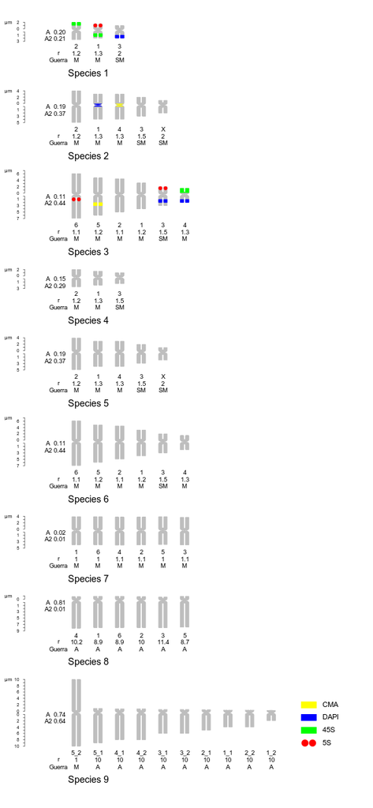

```r
# png("bigdfOfChrSize.png", width=650, height=1300)
par(mar = c(0, 0, 0, 0))
plotIdiograms(dfChrSize  =bigdfOfChrSize,# chr. sizes
              dfMarkColor=dfMarkColor,   # mark characteristics, optional in dev version. see above.
              dfMarkPos  =bigdfOfMarks,  # mark positions (inc. cen. marks)

              karHeight=2.5,             # karyotype rel. height
              karHeiSpace=6,             # karyotype vertical size with spacing
              chrWidth = .35,            # chr. width
              amoSepar = 2,              # Vertical separation of kar. when karSepar = TRUE

              squareness = 10,           # squareness of chr. vertices
              distTextChr=.8,            # distance of chr. to text
              chrIndex = "AR",           # add arm ratio only. For v. >=1.12
              nameChrIndexPos = 3,
              morpho="Guerra",           # add chr. morphology by Guerra, see above. For v. >=1.12
              indexIdTextSize=.6,        # font size of indices and chr. name
              OTUTextSize=.9,            # font size of OTU names

              markLabelSize=.7,          # font size of legend
              fixCenBorder = TRUE,       # use chrColor as border color of cen. or cen. marks
              legendHeight = 2,          # height of labels

              rulerPos=-1,               # position of ruler
              # rulerPosMod=3,           # modify position of ruler
              ruler.tck=-0.004,          # size and orient. of ticks in ruler
              rulerNumberPos=.4,         # position of numbers of ruler
              rulerNumberSize=.4,        # font size of ruler
              ylabline = -1,             # ruler units pos.
              rulerTitleSize=.5,         # ruler font size of units (title)

              xlimRightMod = 3,          # modify xlim left argument
              xlimLeftMod = 2,           # modify xlim left argument
              ylimBotMod = 0,            # modify ylim bottom argument
              ylimTopMod = -.3           # modify ylim top argument
              #,asp=1                    # y x aspect ratio
)
```

```r
# dev.off() # for png()
```

top

## 1.6 Example with several species (OTUs) - holo.

To illustrate this, we will load some data.frames from the package

- Chromosome sizes

```r
data(bigdfChrSizeHolo)
```

| OTU | chrName | chrSize |
| --- | --- | --- |
| species one | 1 | 5.1 |
| species one | 2 | 5.0 |
| species one | 3 | 4.9 |
| species one | 4 | 5.2 |
| species two | 1 | 3.0 |
| species two | 2 | 4.0 |
| species two | 3 | 2.0 |
| species two | 4 | 5.0 |
| species three | 1 | 1.5 |
| species three | 2 | 2.0 |
| species three | 3 | 6.0 |
| species three | 4 | 8.0 |

- Mark characteristics, does not require OTU
- d.f optional for ver. > 1.0.0

```r
data(dfMarkColor)
```

| markName | markColor | style |
| --- | --- | --- |
| 5S | red | dots |
| 45S | green | square |
| DAPI | blue | square |
| CMA | yellow | square |

- Mark position

```r
data(bigdfMarkPosHolo)
```

| OTU | chrName | markName | markPos | markSize |
| --- | --- | --- | --- | --- |
| species two | 3 | 5S | 1.0 | 0.5 |
| species two | 3 | DAPI | 2.0 | 0.5 |
| species two | 1 | 45S | 2.0 | 0.5 |
| species two | 2 | DAPI | 2.0 | 0.5 |
| species two | 4 | CMA | 2.0 | 0.5 |
| species two | 4 | 5S | 0.5 | 0.5 |

### Plotting

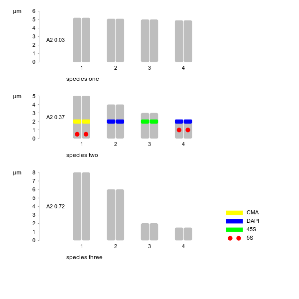

```r
library(idiogramFISH)

# fig.width=6, fig.height=6
png("bigdfChrSizeHolo.png", width=600, height=600)
par(mar=rep(0,4))

plotIdiograms(dfChrSize=bigdfChrSizeHolo, # chr. size data.frame
              dfMarkColor=dfMarkColor,    # df of mark style
              dfMarkPos=bigdfMarkPosHolo, # df of marks' position

              markDistType="cen",         # measure towards center of mark
              squareness=6,               # vertices squareness of chr. and marks

              karHeiSpace = 4,            # karyotype height including spacing
              karSepar=TRUE,              # reduce vertical space among karyotypes
              amoSepar = 1,               # separation among karyotypes
              distTextChr=.5,             # distance text to chr.

              legendWidth = 1             # width of legend labels

              ,chrId="simple",            # numbering of chr., not using "original" name

              indexIdTextSize=.9,         # font size of chr names and indices
              markLabelSize=.9,           # font size of legends

              rulerPos=0,                 # position of ruler
              rulerNumberSize=.9,         # font size of ruler
              ruler.tck= -.004,           # tick length and orient.
              ylabline = -3,              # position of ruler units (title)

              ylimBotMod=.4               # modify ylim bottom argument
              ,xModifier=0.01             # separation among chromatids
)
dev.off()
```

top

## 1.7 GISH of monocentric chromosomes

You need the data.frame of chr. sizes, and a d.f. of marks

### Chr. sizes:

```
parentalAndHybChrSize
```

| OTU | chrName | shortArmSize | longArmSize |
| --- | --- | --- | --- |
| Parental 1 | 1 | 3.2 | 4 |
| Parental 1 | 4 | 1.5 | 2 |
| Parental 1 | 5 | 4.8 | 6 |
| Parental 1 | 6 | 6.1 | 7 |
| Parental 2 | 1 | 3.2 | 4 |
| Parental 2 | 2 | 4.5 | 5 |
| Parental 2 | 3 | 2.0 | 3 |
| Allopolyploid | 1 | 3.2 | 4 |
| Allopolyploid | 2 | 4.5 | 5 |
| Allopolyploid | 3 | 2.0 | 3 |
| Allopolyploid | 4 | 1.5 | 2 |
| Allopolyploid | 5 | 4.8 | 6 |
| Allopolyploid | 6 | 6.1 | 7 |

### Marks’ positions data

```
dfAlloParentMarks
```

| OTU | chrName | markName | chrRegion |
| --- | --- | --- | --- |
| Allopolyploid | 1 | Parental 1 | p |
| Allopolyploid | 1 | Parental 2 | q |
| Allopolyploid | 1 | Parental 2 | cen |
| Allopolyploid | 2 | Parental 2 | w |
| Allopolyploid | 3 | Parental 2 | w |
| Allopolyploid | 4 | Parental 1 | w |
| Allopolyploid | 5 | Parental 1 | w |
| Allopolyploid | 6 | Parental 1 | w |
| Parental 1 | 6 | Parental 1 | w |
| Parental 1 | 5 | Parental 1 | w |
| Parental 1 | 1 | Parental 1 | w |
| Parental 1 | 4 | Parental 1 | w |
| Parental 2 | 2 | Parental 2 | w |
| Parental 2 | 1 | Parental 2 | w |
| Parental 2 | 3 | Parental 2 | w |

```r
# We will use column note to add a note to the right of the karyotype of the OTU in column OTU
notesdf2<-read.table(text=
"           OTU                note
\"Parental 1\"     \"Parental One\"
\"Parental 2\"     \"Parental Two\"
\"Allopolyploid\"  Allopolyploid  ", header=TRUE, stringsAsFactors=FALSE,fill=TRUE)
```

### Plotting

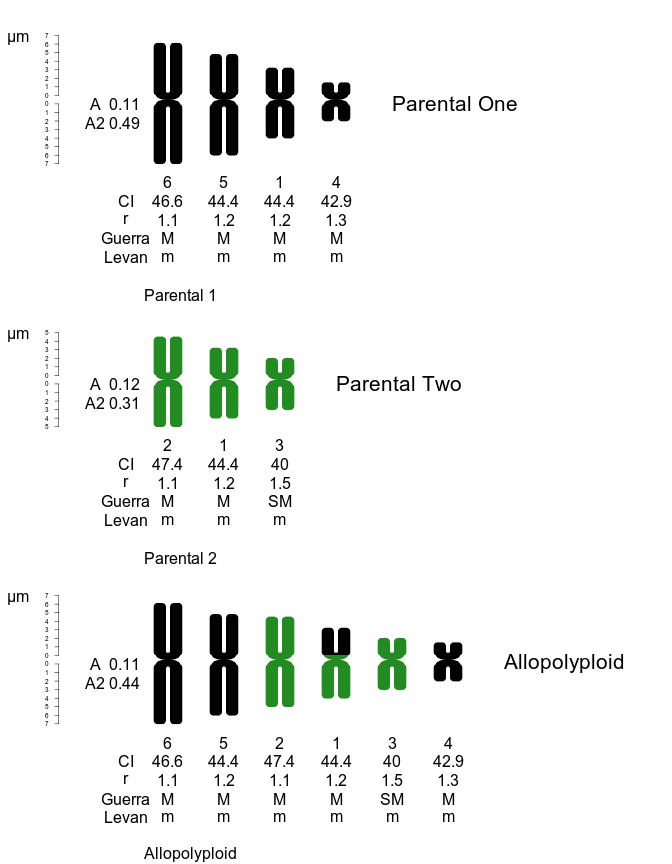

```r
# svg("gish.svg",width=7,height=9 )
#png("parentalAndHybChrSize.png", width=700, height=900)
par(mar=rep(0,4) )
plotIdiograms(dfChrSize = parentalAndHybChrSize,  # d.f. of chr. sizes
              dfMarkPos = dfAlloParentMarks,      # d.f. of marks' positions
              cenColor  = NULL,            # cen. color for GISH

              karHeiSpace=5,               # karyotype height including spacing
              karSepar = FALSE,            # equally sized (height) karyotypes

              rulerPos=-.7,                # ruler position
              ruler.tck= -0.006,           # ruler tick orientation and length
              rulerNumberSize=.4           # ruler font size
              ,ylabline = -1.5             # ruler units pos.

              ,legend=""                   # no legend

              ,notes=notesdf2              # data.frame with notes NEW
              #,OTUasNote=TRUE             # TRY THIS (OTU name to the right)
              ,notesTextSize = 1.3         # font size of notes
              ,notesPos = 1.5              # space from chr. (right) to note

              ,ylimBotMod = 1              # ylim bottom argument mod.
)
```

```r
# dev.off()
```

top

## 1.8 GISH of holocentric chromosomes

You need the data.frame of chr. sizes, and a d.f. of marks

### Chr. sizes:

```
parentalAndHybHoloChrSize
```

| OTU | chrName | chrSize |
| --- | --- | --- |
| Parental 1 | 7 | 4 |
| Parental 1 | 4 | 2 |
| Parental 1 | 5 | 6 |
| Parental 1 | 6 | 7 |
| Parental 2 | 1 | 4 |
| Parental 2 | 2 | 5 |
| Parental 2 | 3 | 3 |
| Allopolyploid | 7 | 4 |
| Allopolyploid | 2 | 5 |
| Allopolyploid | 3 | 3 |
| Allopolyploid | 4 | 2 |
| Allopolyploid | 5 | 6 |
| Allopolyploid | 6 | 7 |

### Marks’ positions data

```
dfAlloParentMarksHolo
```

|  | OTU | chrName | markName | chrRegion |
| --- | --- | --- | --- | --- |
| 1 | Allopolyploid | 7 | Parental 1 | w |
| 4 | Allopolyploid | 2 | Parental 2 | w |
| 5 | Allopolyploid | 3 | Parental 2 | w |
| 6 | Allopolyploid | 4 | Parental 1 | w |
| 7 | Allopolyploid | 5 | Parental 1 | w |
| 8 | Allopolyploid | 6 | Parental 1 | w |
| 9 | Parental 1 | 6 | Parental 1 | w |
| 10 | Parental 1 | 5 | Parental 1 | w |
| 11 | Parental 1 | 7 | Parental 1 | w |
| 12 | Parental 1 | 4 | Parental 1 | w |
| 13 | Parental 2 | 2 | Parental 2 | w |
| 14 | Parental 2 | 1 | Parental 2 | w |
| 15 | Parental 2 | 3 | Parental 2 | w |

### Plotting

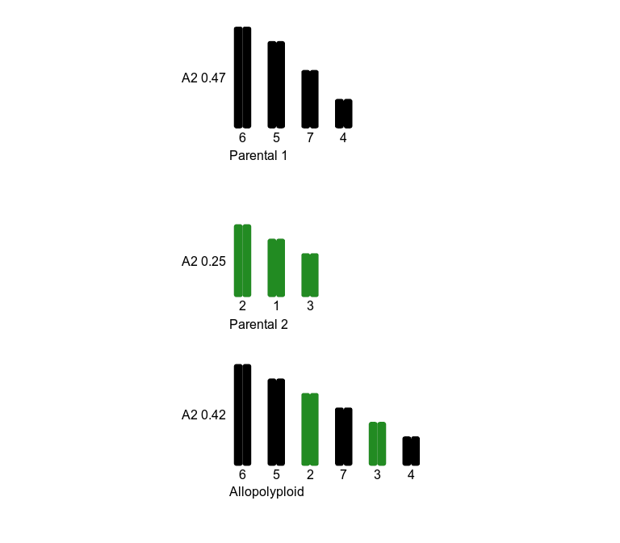

```r
# svg("gish.svg",width=8,height=7 )
par(mar=c(0,0,0,0))
plotIdiograms(dfChrSize = parentalAndHybHoloChrSize,  # d.f. of chr. sizes
              dfMarkPos = dfAlloParentMarksHolo,      # d.f. of marks' positions
              chrColor  = "gray",          # chr. color
              cenColor  = NULL,            # cen. color when GISH

              karHeight = 3,               # karyotype height without spacing
              karHeiSpace=5,               # karyotype height including spacing
              distTextChr = 0.8            # separation among chr. and text

              ,ruler=FALSE                 # no ruler
              ,legend=""                   # no legend

              ,xlimRightMod = 0            # xlim right arg. modif.
              ,xModifier=.005              # separ. among chromatids
)
```

```r
# dev.off()
```

top

## 1.9 Using bases instead of micrometers - no. cen.

Create some data in millions of bases:

```r
# transform previous data.frames for simplicity
bigdfChrSizeHoloMb <- bigdfChrSizeHolo
bigdfChrSizeHoloMb$chrSize <- bigdfChrSizeHoloMb$chrSize * 98000000
bigdfMarkPosHoloMb <- bigdfMarkPosHolo
bigdfMarkPosHoloMb$markPos <- bigdfMarkPosHoloMb$markPos * 98000000
bigdfMarkPosHoloMb$markSize<- bigdfMarkPosHoloMb$markSize * 98000000
```

### Plotting

In the plot length is shown in Mb

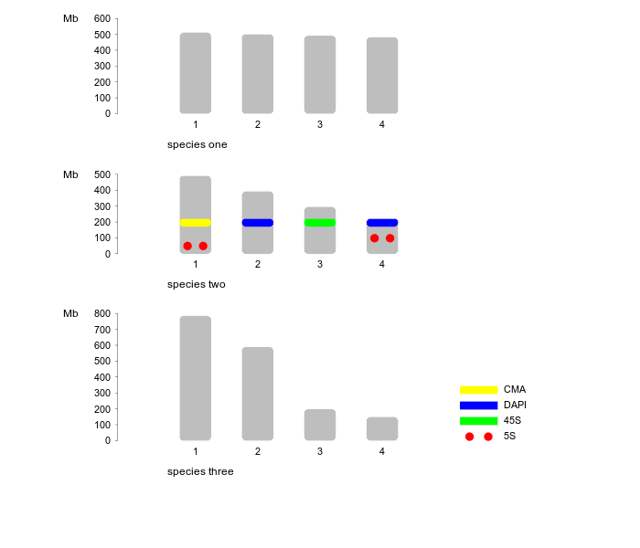

```r
png("bigdfChrSizeHolo2.png", width=700, height=600)
# par(mar=c(1,1,1,1))
par(mar=rep(0,4))

plotIdiograms(dfChrSize=bigdfChrSizeHoloMb,  # chr. size data.frame
              dfMarkColor=dfMarkColor,       # df of mark style
              dfMarkPos=bigdfMarkPosHoloMb,  # df of mark positions

              markDistType="cen",            # distance to mark is to its center
              squareness=4,                  # vertices squareness of chr. and marks
              distTextChr = .5,              # separ. chr. to text

              karHeight = 2,                 # rel. karyotype height
              karHeiSpace = 4,               # karyotype height including spacing
              karSepar=TRUE,                 # reduce spacing among karyotypes
              amoSepar = 1,                  # depends on karSepar, amount of sep.

              chrId="simple",                # chr. names not "original"
              indexIdTextSize=.9,            # font size of chr names and indices
              karIndex = FALSE,              # do not add karyotype asymmetry index

              rulerNumberSize=.9,            # font size of ruler
              rulerPos = 0,                  # position of ruler
              ruler.tck= -.004,              # ruler tick length and orient.
              ylabline = -6,                 # modifies position of ruler title (Mb)

              markLabelSize=.9,              # font size of legend
              legendWidth = 1.2,             # width of legends

              xlimLeftMod = 1,               # modify left argument of xlim
              ylimBotMod=.4                  # modify bottom argument of ylim
              ,chromatids=FALSE              # do not show chromatids
              )
dev.off()
```

For another example see: https://stackoverflow.com/questions/33727432/how-to-plot-positions-along-a-chromosome-graphic/57153497#57153497

top

## 1.10 Using `threshold` to fix scale

The default value of `35` for `threshold` may shrink one of the OTUs of this example more than expected. In this case `threshold` must be bigger.

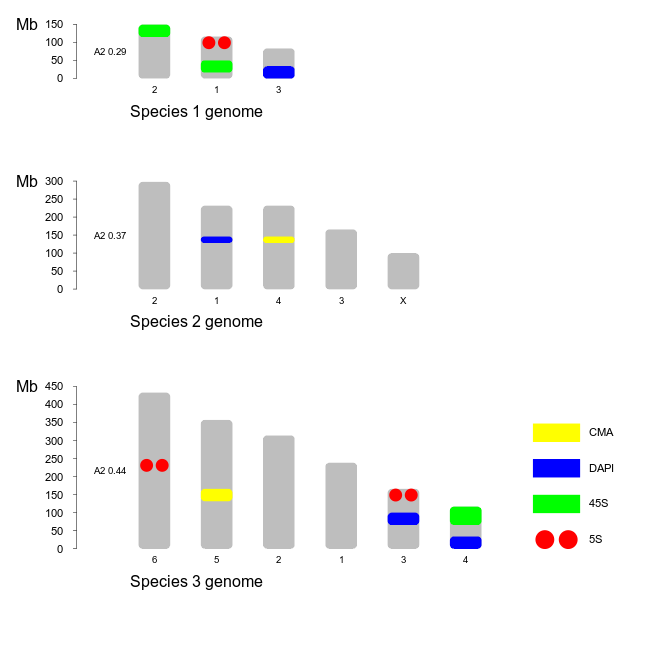

```r
# fig.width=7, fig.height=7
bigdfOfChrSize3_100Mb<-bigdfOfChrSize3Mb
bigdfOfChrSize3_100Mb$chrSize<-bigdfOfChrSize3Mb$chrSize*33

bigdfOfMarks3_100Mb<-bigdfOfMarks3Mb
bigdfOfMarks3_100Mb$markPos<-bigdfOfMarks3_100Mb$markPos*33
bigdfOfMarks3_100Mb$markSize<-bigdfOfMarks3_100Mb$markSize*33

par(mar=rep(0,4))
plotIdiograms(dfChrSize   = bigdfOfChrSize3_100Mb,  # chr. size data.frame
              dfMarkPos   = bigdfOfMarks3_100Mb,    # mark position df

              chrWidth=.6,                # width of chr.
              chrSpacing = .6,            # space among chr.
              karHeight = 3,              # kar. height without interspace
              karHeiSpace = 5,            # vertical size of karyotype including spacer
              amoSepar =2,                # separ. among kar.

              indexIdTextSize=.6,         # font size of chr. name and indices
              markLabelSize=.7,           # font size of mark legends
              distTextChr = .65,          # separation among chr. names and indices

              fixCenBorder = TRUE         # use chrColor as border color of cen. or cen. marks
              ,legendWidth = 1.5          # legend items width

              ,ylabline = -2              # position of Mb (title) in ruler
              ,rulerPos= 0,               # ruler position
              ruler.tck=-0.005,           # ticks of ruler size and orientation
              rulerNumberPos =.7,         # position of numbers in ruler
              rulerNumberSize=.7,         # font size of ruler numbers
              rulerInterval = 1.5,        # ruler interval for micrometeres
              rulerIntervalMb = 50000000, # ruler interval for Mb

              ylimBotMod = 0.4,           # modify ylim bottom argument
              ylimTopMod = 0              # modify ylim top argument
              ,chromatids=FALSE           # do not show chromatids

                         ####  NEW    #####
              ,threshold = 90             # this will allow to not to shrink data greater than 350 Mb
)
```

top

## 1.11 Plot data in micrometers and bases

Info in number of bases can be combined in the same plot with info. in micrometers.

Here the new mark style `cenStyle` is used to add centromeres to “holocen.” (genomes).

To make the rules fit better, having less excess of length over chr., use `ceilingFactor`.

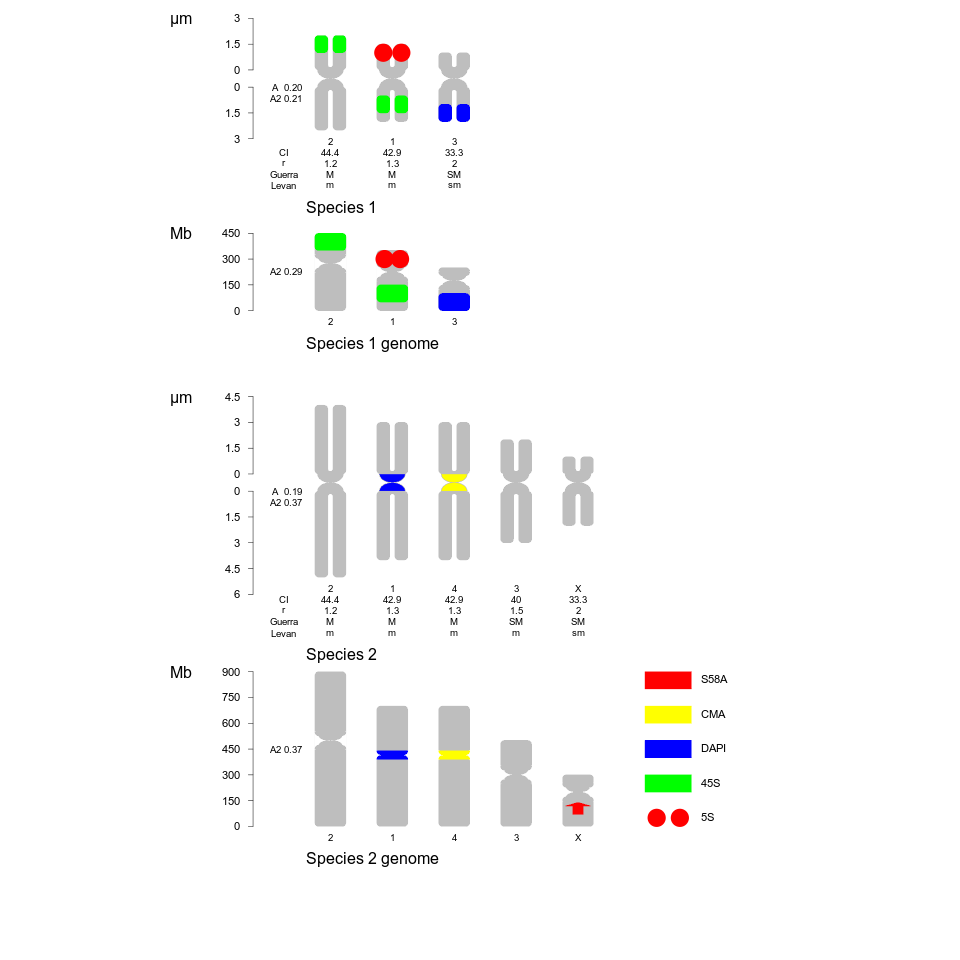

```r
#fig.width=10, fig.height=10
# modify data in millions to hundreds of millions of Mb
bigdfOfChrSize3_100Mb<-bigdfOfChrSize3Mb[1:8,]
bigdfOfChrSize3_100Mb$chrSize<-bigdfOfChrSize3_100Mb$chrSize*100

bigdfOfMarks3_100Mb<-bigdfOfMarks3Mb
bigdfOfMarks3_100Mb$markPos <-bigdfOfMarks3_100Mb$markPos *100
bigdfOfMarks3_100Mb$markSize<-bigdfOfMarks3_100Mb$markSize*100

# merge data.frames in micrometers and number of bases
mixedThreeSpChrSize <- plyr::rbind.fill(bigdfOfChrSize[1:8,], bigdfOfChrSize3_100Mb)
# sort by OTU name
mixedThreeSpChrSize <- mixedThreeSpChrSize[order(mixedThreeSpChrSize$OTU),]

# add cenStyle marks to simulate centromeres in karyo. in Mb (holocen.)
# compare rulers
bigdfSimCenMarks<- bigdfOfChrSize3_100Mb
bigdfSimCenMarks$markPos<-bigdfSimCenMarks$chrSize/2

bigdfSimCenMarks$markName<-"sim. cen."
bigdfSimCenMarks$chrSize<-NULL

# merge marks in micrometers and bases
mixedThreeSpMarks <- plyr::rbind.fill(bigdfOfMarks , bigdfOfMarks3_100Mb,bigdfSimCenMarks)

# remove cenStyle mark info.
mixedThreeSpMarks<-mixedThreeSpMarks[which(!( mixedThreeSpMarks$OTU %in% "Species 2 genome" &
                          mixedThreeSpMarks$chrName %in% c(1,4) &
                          mixedThreeSpMarks$markName %in% "sim. cen.") ),]

# constric. marks
mixedThreeSpMarks[which(mixedThreeSpMarks$OTU %in% "Species 2 genome" &
                          mixedThreeSpMarks$chrName %in% c(1,4) ),]$markName<-c("cDAPI","cCMA")

# add arrow mark
mixedThreeSpMarks <- dplyr::bind_rows(mixedThreeSpMarks , mixedThreeSpMarks[nrow(mixedThreeSpMarks),] )
mixedThreeSpMarks[nrow(mixedThreeSpMarks),]$markName<-"S58A"
mixedThreeSpMarks[nrow(mixedThreeSpMarks),]$markPos<-.7e+08
mixedThreeSpMarks[nrow(mixedThreeSpMarks),]$markSize<-.7e+08

dfMarkColorAndStyle<-idiogramFISH:::makedfMarkColorMycolors(unique(mixedThreeSpMarks$markName),
                                                            c("red","green","blue","yellow","blue","yellow","black")
)

# d.f. of marks'styles

dfMarkColorAndStyle$style[5:7]<-"cenStyle"
dfMarkColorAndStyle$markColor[7]<-NA
dfMarkColorAndStyle$style[8]<-"upArrow"

dfMarkColorAndStyle
#    markName markColor    style
# 1        5S       red     dots
# 2       45S     green   square
# 3      DAPI      blue   square
# 4       CMA    yellow   square
# 5     cDAPI      blue cenStyle
# 6      cCMA    yellow cenStyle
# 7 sim. cen.      <NA> cenStyle
# 8      S58A       red  upArrow

par(mar=rep(0,4))
plotIdiograms(dfChrSize   = mixedThreeSpChrSize,  # chr. size data.frame
              dfMarkPos   = mixedThreeSpMarks,    # mark position df
              dfMarkColor = dfMarkColorAndStyle,

              chrWidth=.6,                # width of chr.
              chrSpacing = .6,            # space among chr.
              karHeight = 3,              # kar. height without interspace
              karHeiSpace = 5,            # vertical size of karyotype including spacer
              amoSepar =2,                # separ. among kar.

              indexIdTextSize=.6,         # font size of chr. name and indices
              markLabelSize=.7,           # font size of mark legends
              distTextChr = .65,          # separation among chr. names and indices
              lwd.mimicCen = 1.5,         # constric. line width

              legendWidth = 1.5,          # legend items width
              fixCenBorder = TRUE,        # use chrColor as border color of cen. or cen. marks

              ylabline = -10,             # position of Mb (title) in ruler
              rulerPos= 0,                # ruler position
              ruler.tck=-0.005,           # ticks of ruler size and orientation
              rulerNumberPos =.7,         # position of numbers in ruler
              rulerNumberSize=.7,         # font size of ruler numbers
              rulerInterval = 1.5,        # ruler interval for micrometeres
              rulerIntervalMb = 150000000,# ruler interval for Mb
              ceilingFactor = 1,          # affects rounding for ruler max. value

              ylimBotMod = 0.4,           # modify ylim bottom argument
              ylimTopMod = 0              # modify ylim top argument
              ,holocenNotAsChromatids = TRUE # do not use chromatids in holocen.
              ,pattern="^c"               # regex pattern to remove from mark names
              ,remSimiMarkLeg = TRUE      # remove pseudoduplicate names arising from pattern removal
)
```

Let’s explore those data.frames

```r
head(mixedThreeSpChrSize,6)
```

|  | OTU | chrName | shortArmSize | longArmSize | chrSize |
| --- | --- | --- | --- | --- | --- |
| 1 | Species 1 | 1 | 1.5 | 2.0 | NA |
| 2 | Species 1 | 2 | 2.0 | 2.5 | NA |
| 3 | Species 1 | 3 | 1.0 | 2.0 | NA |
| 9 | Species 1 genome | 1 | NA | NA | 3.5e+08 |
| 10 | Species 1 genome | 2 | NA | NA | 4.5e+08 |
| 11 | Species 1 genome | 3 | NA | NA | 2.5e+08 |

```r
mixedThreeSpMarks[which(mixedThreeSpMarks$OTU %in% c("Species 1","Species 1 genome") ),]
```

|  | OTU | chrName | markName | chrRegion | markDistCen | markSize | markPos |
| --- | --- | --- | --- | --- | --- | --- | --- |
| 1 | Species 1 | 1 | 5S | p | 0.5 | 1 | NA |
| 2 | Species 1 | 1 | 45S | q | 0.5 | 1 | NA |
| 3 | Species 1 | 2 | 45S | p | 1.0 | 1 | NA |
| 4 | Species 1 | 3 | DAPI | q | 1.0 | 1 | NA |
| 13 | Species 1 genome | 1 | 5S | NA | NA | 100000000 | 250000000 |
| 14 | Species 1 genome | 1 | 45S | NA | NA | 100000000 | 50000000 |
| 15 | Species 1 genome | 2 | 45S | NA | NA | 100000000 | 350000000 |
| 16 | Species 1 genome | 3 | DAPI | NA | NA | 100000000 | 0 |
| 25 | Species 1 genome | 1 | sim. cen. | NA | NA | NA | 175000000 |
| 26 | Species 1 genome | 2 | sim. cen. | NA | NA | NA | 225000000 |
| 27 | Species 1 genome | 3 | sim. cen. | NA | NA | NA | 125000000 |

top

## 1.12 Use cM as units

Info in cM can be combined in the same plot with info. in micrometers.

To make the rules fit better, having less excess of length over chr., use `ceilingFactor`.

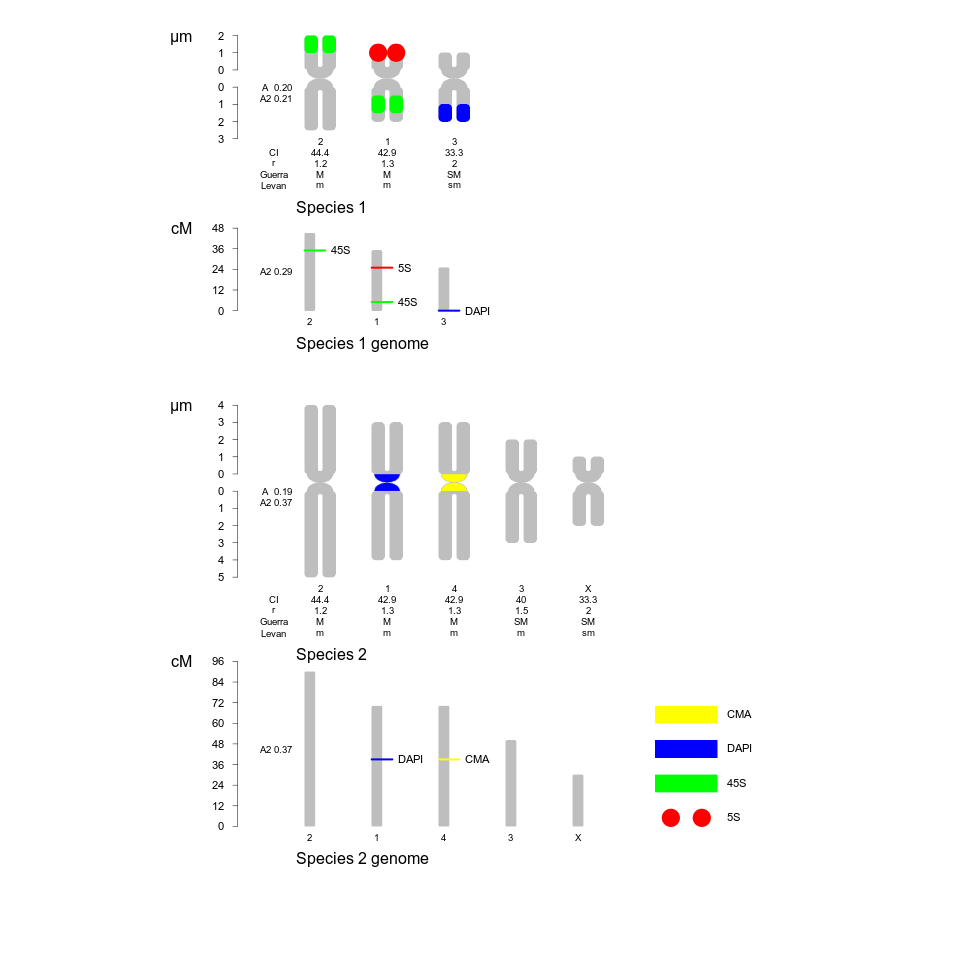

```r
#fig.width=10, fig.height=10
# merge data.frames in micrometers and cM
bigdfOfChrSize3cM<-bigdfOfChrSize3Mb[1:8,]
bigdfOfChrSize3cM$chrSize<-bigdfOfChrSize3cM$chrSize/100000
mixedThreeSpChrSize <- plyr::rbind.fill(bigdfOfChrSize[1:8,], bigdfOfChrSize3cM)

# sort by OTU name
mixedThreeSpChrSize <- mixedThreeSpChrSize[order(mixedThreeSpChrSize$OTU),]

# create data with cM. markSize col. is not necessary because style is cM
bigdfOfMarks3cM<-bigdfOfMarks3Mb
bigdfOfMarks3cM$markPos<-bigdfOfMarks3Mb$markPos/100000
bigdfOfMarks3cM$markSize<-NA
# As we want only the cM idiograms to be plotted as cM (lines), change mark names
bigdfOfMarks3cM$markName<-paste0("cM",bigdfOfMarks3cM$markName)

# d.f of all marks
mixedThreeSpMarks <- plyr::rbind.fill(bigdfOfMarks , bigdfOfMarks3cM)

# create a data.frame with mark characteristics
mixedDfMarkStyle  <- idiogramFISH:::makedfMarkColorMycolors(unique(mixedThreeSpMarks$markName),
                                                            c("red","green","blue","yellow")
                                                            )

# mark names of cM marks with "cM" style (lines): not dots, not squares
mixedDfMarkStyle[which(mixedDfMarkStyle$markName %in%
                         grep("cM", mixedDfMarkStyle$markName, value=TRUE) ) ,]$style<-"cM"

par(mar=rep(0,4))
plotIdiograms(dfChrSize   = mixedThreeSpChrSize,  # chr. size data.frame
              dfMarkPos   = mixedThreeSpMarks,    # mark position data.frame
              dfMarkColor = mixedDfMarkStyle,     # mark style data.frame

              chrWidth=.6,                # width of chr.
              chrSpacing = .7,            # space among chr.

              specialOTUNames = bigdfOfMarks3cM$OTU, # OTUs in this object will have different ruler units
              specialyTitle = "cM",       # ruler title for specialOTUNames
              specialChrWidth = .2,       # modify chr width of OTUs in specialOTUNames
              specialChrSpacing = 1.1,    # modify chr spacing of OTUs in specialOTUNames

              karHeight = 3,              # kar. height without interspace
              karHeiSpace = 5,            # vertical size of karyotype including spacer
              amoSepar =2,                # separ. among kar.

              indexIdTextSize=.6,         # font size of chr. name and indices
              distTextChr = .65,          # separation among chr. names and indices

              protruding = 1,             # extension of cM mark type
              pattern = "cM",             # regex pattern to remove from mark names
              markLabelSize=.7            # font size of mark legends
              ,legendWidth = 2            # legend items width
              ,fixCenBorder = TRUE        # use chrColor as border color of cen. or cen. marks
              ,lwd.cM = 2                 # thickness of cM marks
              ,holocenNotAsChromatids=TRUE# do not use chromatids in holocen. kar.

              ,ylabline = -10             # position of Mb or cM (title) in ruler
              ,rulerPos= 0,               # ruler position
              ruler.tck=-0.005,           # ticks of ruler size and orientation
              rulerNumberPos =.7,         # position of numbers in ruler
              rulerNumberSize=0.7,        # font size of ruler numbers
              rulerIntervalcM = 12,       # ruler interval for OTU in specialOTUnames and MbThreshold not met
              ceilingFactor = 1,          # affects max. value in ruler. See also rulerInterval

              ylimBotMod = 0.4,           # modify ylim bottom argument
              ylimTopMod = 0              # modify ylim top argument
)
```

top

## 1.13 Using groups - mono.

### Adding the column `group`

Open your chromosome data - Chr. size - as data.frame and add column

```r
# Example data.frame written in R, use
dfwithgroups<-read.table(text="
      chrName shortArmSize longArmSize group
1        1            3           5     1
2        1            3.2         5.5   1
3        1            3.5         4.8   1
4        4            1           3     NA
5        5            3           5     NA
6        X            4           6     NA", header=TRUE, stringsAsFactors=F)
```

| chrName | shortArmSize | longArmSize | group |
| --- | --- | --- | --- |
| 1 | 3.0 | 5.0 | 1 |
| 1 | 3.2 | 5.5 | 1 |
| 1 | 3.5 | 4.8 | 1 |
| 4 | 1.0 | 3.0 | NA |
| 5 | 3.0 | 5.0 | NA |
| X | 4.0 | 6.0 | NA |

### Heteromorphic pairs

It can be used to plot heteromorphic pairs, see pair 1

```r
dfwithHetero<-read.table(text="
       chrName shortArmSize longArmSize group
1        1A           3           5     1
2        1B           3           5     1
4        2            1           3     NA
5        3            3           5     NA
6        4            4           6     NA", header=TRUE, stringsAsFactors=FALSE)
```

|  | chrName | shortArmSize | longArmSize | group |
| --- | --- | --- | --- | --- |
| 1 | 1A | 3 | 5 | 1 |
| 2 | 1B | 3 | 5 | 1 |
| 4 | 2 | 1 | 3 | NA |
| 5 | 3 | 3 | 5 | NA |
| 6 | 4 | 4 | 6 | NA |

Open or write your mark positions as a data.frame. This data.frame has the marks present in all karyotypes with position info.

```r
dfOfMarksHetero<-read.table(text=
"     chrName markName chrRegion markSize markDistCen
1       1A       5S       p        1         0.9
2       1B      45S       p        1         0.9
3       2       CMA       q        1         1.0
4       3      DAPI       q        1         1.0", header=TRUE, stringsAsFactors=FALSE)
```

| chrName | markName | chrRegion | markSize | markDistCen |
| --- | --- | --- | --- | --- |
| 1A | 5S | p | 1 | 0.9 |
| 1B | 45S | p | 1 | 0.9 |
| 2 | CMA | q | 1 | 1.0 |
| 3 | DAPI | q | 1 | 1.0 |

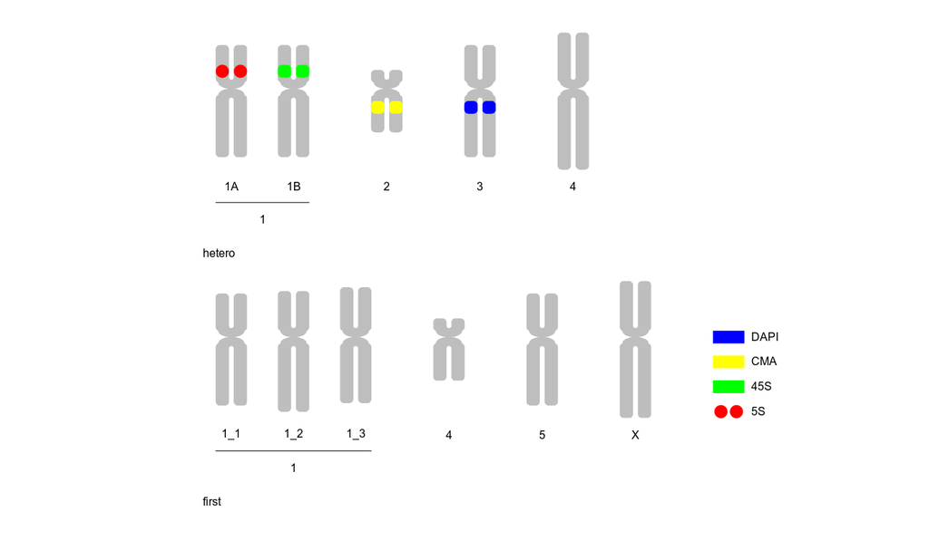

```r
# svg("dfwithHetero.svg",width=13.5,height=8 )
par(mar=rep(0,4))

dfwithHetero$OTU<-"hetero"
dfwithgroups$OTU<-"first"
both<-plyr::rbind.fill(dfwithHetero,dfwithgroups)
dfOfMarksHetero$OTU<-"hetero"
plotIdiograms(dfChrSize=both,    # chr. sizes
              dfMarkPos=dfOfMarksHetero, # position of marks
              karHeiSpace = 4,

              chrId="original",          # chr. name in df.
              chrIndex = "",             # do not add chr. indices
              morpho="",                 # do not add chr. morphologies
              karIndex = FALSE,          # do not add karyotype indices
              distTextChr = .8,          # distance from text to chr.

              markDistType="cen",        # mark position measured to center of mark
              orderChr = "name",       # order chr. by name

              ruler=FALSE                # do not plot ruler

              ,ylimBotMod = 1            # modify ylim bottom argument
              ,legendWidth = 1           # width of legend
)
```

```r
# dev.off()
```

top

## 1.14 Holocentrics in groups

Let’s modify some data.frames to add a group

```r
data("dfChrSizeHolo")
data("dfMarkPosHolo")
dfMarkPosHoloHetero<-dfMarkPosHolo
dfMarkPosHoloHetero$chrName<-c(3,3,"1A",2,"1B","1B")
dfMarkPosHoloHetero$OTU<-"heteromorphic"

dfChrSizeHoloHetero<-dfChrSizeHolo
dfChrSizeHoloHetero$chrName<-c("1A","1B",2,3)
dfChrSizeHoloHetero$OTU<-"heteromorphic"

# Adding the group column
dfChrSizeHoloHetero$group<-c(1,1,NA,NA)
```

### Creating a new data.frame for holocentrics

```r
dfChrSizeHoloGroup<-data.frame(OTU="Species name",
                               chrName=c(1,1,1,1,2,3,4),
                               chrSize=c(3.1,3.2,3.3,3.4,4,5,6),
                               group=c(1,1,1,1,NA,NA,NA)
                               )
```

| OTU | chrName | chrSize | group |
| --- | --- | --- | --- |
| Species name | 1 | 3.1 | 1 |
| Species name | 1 | 3.2 | 1 |
| Species name | 1 | 3.3 | 1 |
| Species name | 1 | 3.4 | 1 |
| Species name | 2 | 4.0 | NA |
| Species name | 3 | 5.0 | NA |
| Species name | 4 | 6.0 | NA |

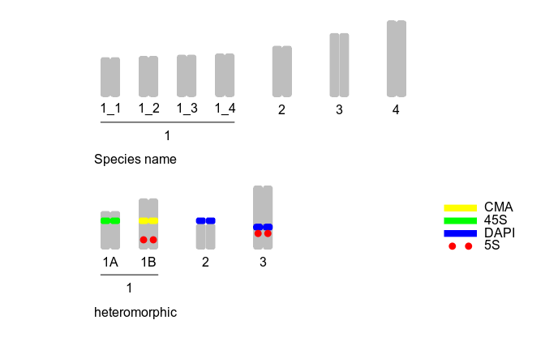

```r
par(mar=rep(0,4))
mergedChrSize<-plyr::rbind.fill(dfChrSizeHoloGroup,dfChrSizeHoloHetero)

plotIdiograms(dfChrSize=mergedChrSize,      # data.frame of chr. sizes
              dfMarkPos=dfMarkPosHoloHetero,# d.f. of marks
              orderChr = "name",          # order chr. by name
              karIndex = FALSE,             # do not add karyotype indices
              addOTUName = TRUE,            # add OTU name
              karHeiSpace = 4,              # height of kar. with spacing

              ruler=FALSE,                  # no ruler

              xlimLeftMod=-1,               # modify left argument of xlim
              xlimRightMod=0,               # modify right argument of xlim
              ylimBotMod=1.3                # modify bottom argument of ylim
              ,xModifier=0.005              # separ. among chromatids
)
```

top

## References

Guerra M. 1986. Reviewing the chromosome nomenclature of Levan et al. *Brazilian Journal of Genetics*, 9(4): 741–743

Levan A, Fredga K, Sandberg AA. 1964. Nomenclature for centromeric position on chromosomes *Hereditas*, 52(2): 201–220. https://doi.org/10.1111/j.1601-5223.1964.tb01953.x. https://onlinelibrary.wiley.com/doi/abs/10.1111/j.1601-5223.1964.tb01953.x

Romero-Zarco C. 1986. A new method for estimating karyotype asymmetry *Taxon*, 35(3): 526–530. https://onlinelibrary.wiley.com/doi/abs/10.2307/1221906

Watanabe K, Yahara T, Denda T, Kosuge K. 1999. Chromosomal evolution in the genus Brachyscome (Asteraceae, Astereae): statistical tests regarding correlation between changes in karyotype and habit using phylogenetic information *Journal of Plant Research*, 112: 145–161. http://link.springer.com/article/10.1007/PL00013869